# Text Mining approach to analyze news articles

Mateusz Cedro Jan Dudzik Weronika Kalita

Feb 2023

### 1. Introduction

In recent years, with the growth of digital media, the amount of news content being generated every day has increased dramatically. As a result, there is a growing need for methods to quickly and accurately analyze this vast amount of information. Text mining can help extract insights and trends from news articles, and is widely used in areas such as sentiment analysis, topic modeling, and information retrieval. Especially when it comes to news articles, there is significant need to understand how they work and how to interact with those, therefore in this article, we will explore the various techniques used in text mining field, to analyze existing topics and sentiments present in 6877 articles grouped into 14 categories published on Huffpost website. We will examine the top topics across articles, determine if the sentiments vary between categories and how topics are similar to the body of articles.

### 2. Data

- Description of the data set
- Preparation of data for modeling

The dataset contains 6877 unique articles within 14 categories including Arts & Culture, Business, Comedy, Crime, Education, Entertainment, Environment, Media, Politics, Religion, Science, Sports, Tech and Women. The articles spreads almost equally across categories and after initial analysis, we have removed common stopwords, in order to understand the most used words within our articles.

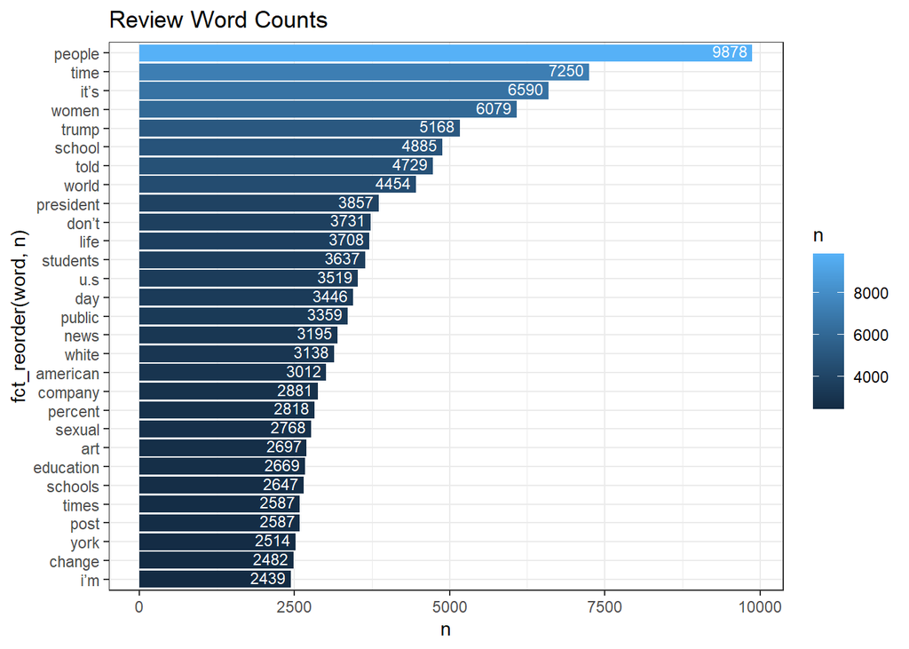

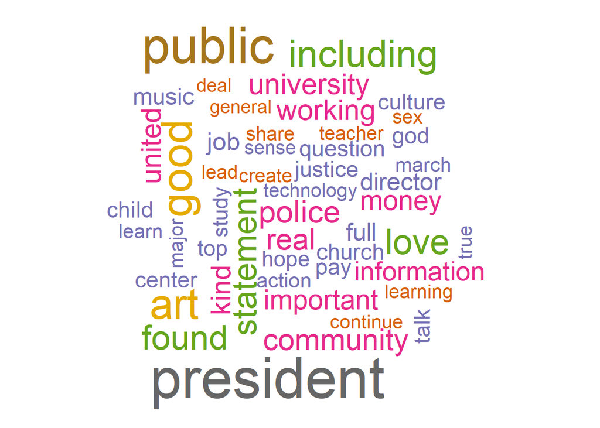

[figure not shown]

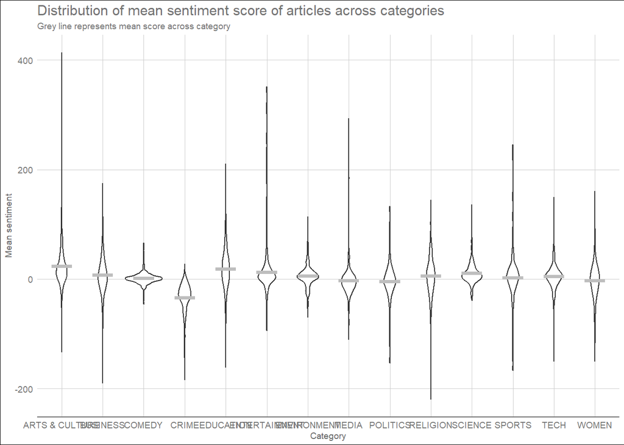

```r
violin_afinn
```

### 3. Modeling

In the modeling part, we will evaluate the LDA method to identify common topics of articles. Latent Dirichlet Allocation (LDA) is a generative probabilistic model used for topic modeling in text analysis. It assumes that each document in a corpus is generated from a mixture of latent topics and each topic is characterized by a distribution over words. The method uses Bayesian inference to estimate the topic and word distributions in a corpus, and it can be used to identify the underlying topics in a collection of documents. The results of LDA can be generally used for tasks such as document clustering, topic classification, and information retrieval. What is more, we will also analyze how the Sentiments spread across categories and if they differ between article Title and Body. In order to achieve that, we will assign sentiments to each of the words in title and body, then calculate percentage of words of each sentiment in relation to number of all words used in title/article. After that, for every row we calculate the Euclidean distance between the vector of sentiments for title and for body and take the average of that distance for every category and compare those scores.

### 4. Evaluation (quality of obtained results)

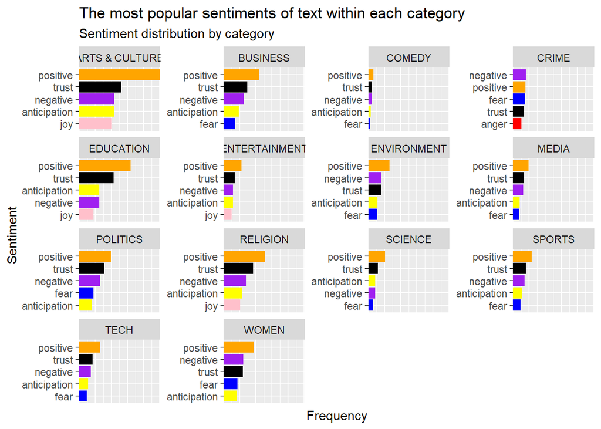

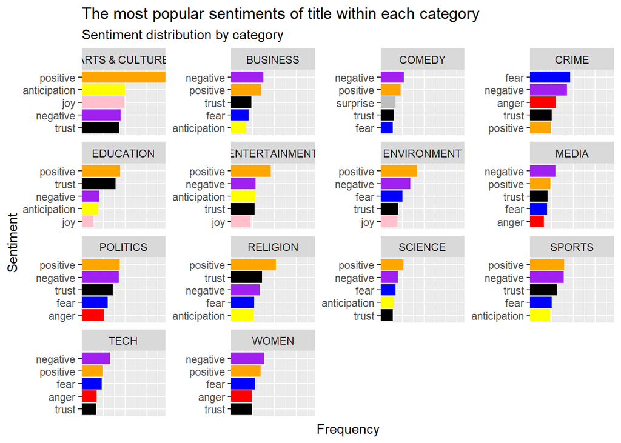

As we can inspect above, Positive sentiment is dominant in every category, except Crime, where it still takes a second place. Although when it comes to Titles, it’s not that obvious and there are many categories, that do not have positive sentiment at the first place. Interesting examples are Comedy, Business, Media, Tech and Women, which have negative as a most popular category. This discrepancy of sentiments is worth further investigation, so in the next step, we will check the distances between the vectors of sentiments for each title and body of articles.

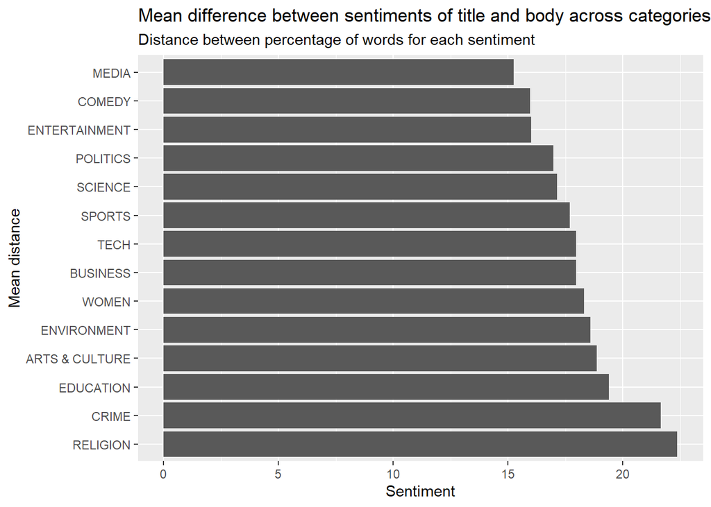

Let’s see the basic outcome from the LDA algorithm below:

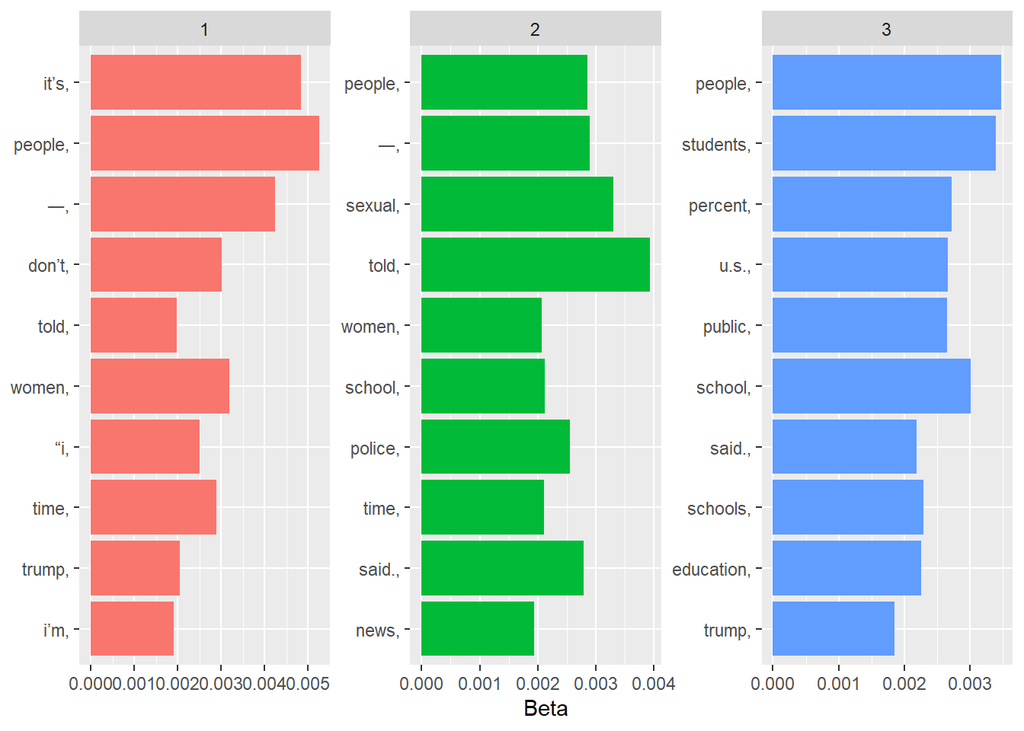

Since LDA works like PCA but for text analysis we can model all the topics within text documents by reduce the ‘dimensionality’ of the topics. It is done by decomposition of the corpus document word matrix (the larger matrix) into two parts (smaller matrices): the Document Topic Matrix and the Topic Word.

This visualization lets us understand the three topics that were extracted from the dataset. The most common words in topic 1 include “people”, “women”, “time”, and “trump”, which suggests it may represent either sociological or political news. Those most common in topic 2 include “people”, “sexual”, “women”, “school”, and “police”, suggesting that this topic represents political news. One important observation about the words in each topic is that some words, such as “women” and “people”, are common within both topics. Third topic contains, again, “people”, but also “students”, “percent”, “u.s.” and, school”.

As stated in article from tidytextmining.com “This is an advantage of topic modeling as opposed to “hard clustering” methods: topics used in natural language could have some overlap in terms of words.”

We have tried to delete both common and document-specific stopword, however, not knowing why, we still struggled up with some of them… (We will be very happy to recieve your feedback on that issue because even with much effort putted in trying to remove them, we could not do it finally)

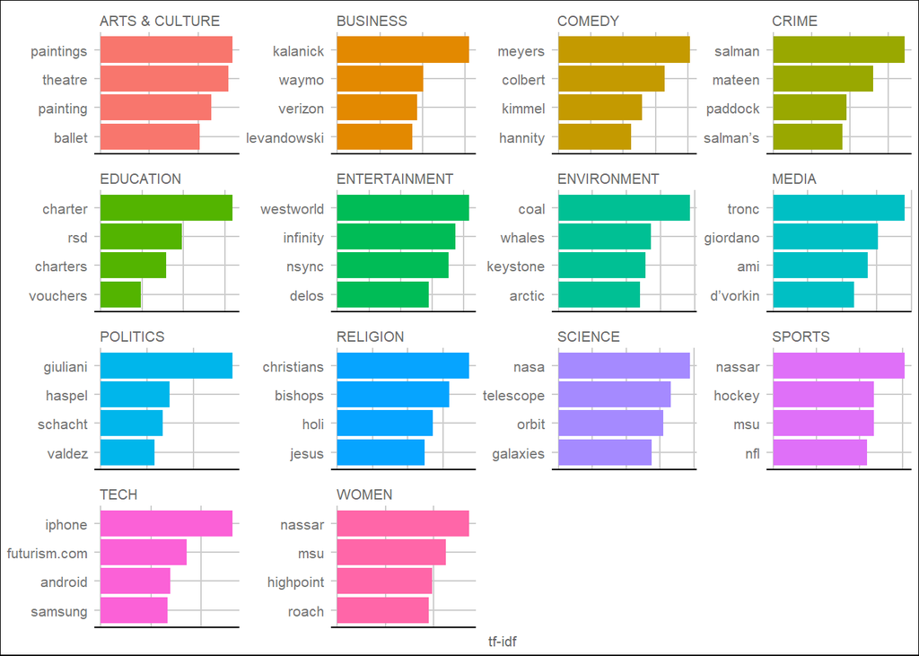

Term frequency-inverse document frequency (TF-IDF) tells us quantitatively how rare the term is. Accordingly to the Medium.com article: The score increases the more frequently a term occurs. However, it decreases the more often the term appears across multiple documents. We can also think of TF-IDF in this way: “How strange is it that this token is in this document?”

### 5. Summary

We did examine the hypothesis of if the sentiment vary between title and the article itself, coming to the conclusion, that sentiment is different for those, especially for Religion and Crime news. We have conducted the LDA method to find common topics and used TF-IDF matrix to understand commonly used terms.